# Programación para *Data Science*

## Unidad 7: Análisis de datos en Python

# Introducción

En este Notebook encontraréis dos conjuntos de ejercicios: un primer conjunto de **ejercicios para practicar** y un segundo conjunto de **actividades evaluables** como PEC de la asignatura.

En cuanto al conjunto de ejercicios para practicar, éstos no puntúan para la PEC, pero os recomendamos que los intentéis resolver como parte del proceso de aprendizaje. Encontraréis ejemplos de posibles soluciones a los ejercicios al propio notebook, pero es importante que intentéis resolverlos vosotros antes de consultar las soluciones. Las soluciones os permitirán validar vuestras respuestas, así como ver alternativas de resolución de las actividades. También os animamos a preguntar cualquier duda que surja sobre la resolución de los **ejercicios para practicar** en el foro del aula.

En relación a las actividades evaluables, veréis que cada una de ellas tiene asociada una puntuación que indica el peso que tiene la actividad sobre la nota de la PEC. Adicionalmente, hay un ejercicio opcional, que no tiene puntuación dentro de la PEC, pero que se valora al final del semestre de cara a conceder las matrículas de honor y redondear las notas finales. Podéis sacar la máxima nota de la PEC sin necesidad de hacer este ejercicio! El objetivo de este ejercicio es que sirva como pequeño reto para los estudiantes que quieran profundizar en el contenido de la asignatura.

Además, veréis que todas las actividades tienen una etiqueta que indica los recursos necesarios para llevarla a cabo. Hay tres posibles etiquetas:

- NM **Sólo materiales**: las herramientas necesarias para realizar la actividad se pueden encontrar en los materiales de la asignatura.
- EG **Consulta externa guiada**: la actividad puede requerir hacer uso de herramientas que no se encuentran en los materiales de la asignatura, pero el enunciado contiene indicaciones de dónde o cómo encontrar la información adicional necesaria para resolver la actividad.
- EI **Consulta externa independente**: la actividad puede requerir hacer uso de herramientas que no se encuentran en los materiales de la asignatura, y el enunciado puede no incluir la descripción de dónde o cómo encontrar esta información adicional. Será necesario que el estudiante busque esta información utilizando los recursos que se han explicado en la asignatura.

Es importante notar que estas etiquetas no indican el nivel de dificultad del ejercicio, sino únicamente la necesidad de consulta de documentación externa para su resolución. Además, recordad que las **etiquetas son informativas**, pero podréis consultar referencias externas en cualquier momento (aunque no se indique explícitamente) o puede ser que podáis hacer una actividad sin consultar ningún tipo de documentación. Por ejemplo, para resolver una actividad que sólo requiera los materiales de la asignatura, puedéis consultar referencias externas si queréis, ya sea tanto para ayudaros en la resolución como para ampliar el conocimiento!

En cuanto a la consulta de documentación externa en la resolución de los ejercicios, recordad **citar siempre la bibliografía utilizada** para resolver cada actividad.

### Alumno: Nicolás D'Alessandro

## Ejercicios y preguntas teóricas para la PEC

A continuación, los ejercicios que se deben completar en esta PEC y que forman parte de la evaluación de esta unidad.

## Pregunta 1

Investiga y describe el funcionamiento del algoritmo de clustering *Leave One Out*. Pon un ejemplo de aplicación del algoritmo para resolver un problema de análisis en el ámbito de la salud. Recordad que hay que citar las referencias consultadas para responder la pregunta, y que la respuesta que proporcionéis debe ser original (redactada por vosotros mismos, después de haber leído y entendido las referencias que consideréis oportunas). **(1 punto)** EG

**Leave One Out** es una de las diferentes técnicas de "model validation" que existen para estimar la "accuracy" de, en este caso, un modelo de ML.

1) Antes de definir este concepto, debemos entender que es la validación cruzada (mas conocida como **"cross-validation"** por su denominación en Ingles), cuyo objetivo es medir la habilidad que nuestro modelo tiene para predecir o clasificar (dependiendo el tipo de problema planteado) cuando se prueba en data que no has sido utilizada para el entrenamiento del modelo. Cabe aclarar, que para realizar un problema de ML dividimos nuestro dataset original en dos: un dataset "train" y otro "test".

2) Una vez tenemos claro el concepto de cross-validation, podemos profundizar en la definición de **"leave-one-out"** que pide el enunciado. Esta técnica de validación-cruzada consiste en separar los datos con el fin de realizar una iteración con un solo un valor del dataset para "test" y todo los valores restantes como datos de entrenamiento. Por tanto, se realizarán tantas iteraciones como muestras tenga el dataset, habiendo para cada una de las N iteraciones un cálculo de error. El resultado final lo obtenemos realizando la "media aritmética" de los N valores de errores obtenidos. Es evidente que este tipo de validación cruzada implica un costo computacional muy alto, sobre todo en datasets de gran volumen.

[figure not shown]

## Pregunta 2

Debemos evitar evaluar los modelos con los mismos datos que se han utilizado para el aprendizaje. De no hacerlo, podríamos favorecer el problema del **sobre-ajuste**. ¿En qué consiste este problema y qué consecuencias puede tener? **(0,5 puntos)** EI

Como hemos dicho anteriormente, cuando realizamos un problema de ML separamos nuestro dataset en **"train"** y **"test"**, de modo de entrenar y obtener el modelo con el primero y medir la efectividad frente a datos desconocidos con el segundo. Al trabajar de esta manera, nuestro modelo es siempre suceptible al error o problema de sobre-ajuste (más conocido como **"overfitting"** por su definición en Ingles). El sobre ajuste se produce cuando nuestro modelo es capaz de predecir o clasificar de manera muy efectiva con nuestro dataset de entrenamiento, pero falla al hacerlo con nuestra data "test". Este problema se da de manera muy recurrente en la elaboración de modelos de ML, y técnicas de cross validation como la explicada en la primera pregunta, son utilizadas justamente para detectar este problema.

[figure not shown]

## Ejercicio 1

En los siguientes ejercicios de la PEC usaremos el conjunto de datos del dataset `breast_cancer` de *sklearn*. Crea una tabla con los estadísticos descriptivos de todas las características de los tumores de la base de datos `breast_cancer` agrupados por tipo (benigno/maligno).

Realizad un test estadístico [ttest](https://docs.scipy.org/doc/scipy/reference/generated/scipy.stats.ttest_ind.html) para comparar el error de la simetría (*symmetry error*) y tersura (*mean smoothness*) de los tumores benignos con las de los malignos. Dado el resultado obtenido, indica qué características podrían ser más relevantes para diagnosticar un tumor maligno.

Nota: Consulta este [enlace](http://www.conexionismo.com/leer_articulo.php?ref=prueba_t_de_student_para_la_comparacion_de_dos_muestras_independientes-j960497l) si quieres ampliar conocimientos sobre el test estadístico ttest. Para realizar el test estadístico automáticamente podéis utilizar el método [`ttest_ind`](https://docs.scipy.org/doc/scipy/reference/generated/scipy.stats.ttest_ind.html) de *Scipy.stats* **(1 punto)** EG

```python
#importamos las librerias necesarias
import numpy as np
import pandas as pd
import seaborn as sns
import matplotlib.pyplot as plt
from sklearn import datasets
from scipy import stats

#cargamos el dataset solicitado
from sklearn.datasets import load_breast_cancer
```

```python
diagnostics = datasets.load_breast_cancer()
```

```python
columns = diagnostics['feature_names'].tolist()
df = diagnostics['data'].tolist()
```

```python
df = pd.DataFrame(diagnostics['data'], columns=columns)
df = df.assign(target=pd.Series(diagnostics['target']))
df.head()
```

|  | mean radius | mean texture | mean perimeter | mean area | mean smoothness | mean compactness | mean concavity | mean concave points | mean symmetry | mean fractal dimension | ... | worst texture | worst perimeter | worst area | worst smoothness | worst compactness | worst concavity | worst concave points | worst symmetry | worst fractal dimension | target |
| --- | --- | --- | --- | --- | --- | --- | --- | --- | --- | --- | --- | --- | --- | --- | --- | --- | --- | --- | --- | --- | --- |
| 0 | 17.99 | 10.38 | 122.80 | 1001.0 | 0.11840 | 0.27760 | 0.3001 | 0.14710 | 0.2419 | 0.07871 | ... | 17.33 | 184.60 | 2019.0 | 0.1622 | 0.6656 | 0.7119 | 0.2654 | 0.4601 | 0.11890 | 0 |
| 1 | 20.57 | 17.77 | 132.90 | 1326.0 | 0.08474 | 0.07864 | 0.0869 | 0.07017 | 0.1812 | 0.05667 | ... | 23.41 | 158.80 | 1956.0 | 0.1238 | 0.1866 | 0.2416 | 0.1860 | 0.2750 | 0.08902 | 0 |
| 2 | 19.69 | 21.25 | 130.00 | 1203.0 | 0.10960 | 0.15990 | 0.1974 | 0.12790 | 0.2069 | 0.05999 | ... | 25.53 | 152.50 | 1709.0 | 0.1444 | 0.4245 | 0.4504 | 0.2430 | 0.3613 | 0.08758 | 0 |
| 3 | 11.42 | 20.38 | 77.58 | 386.1 | 0.14250 | 0.28390 | 0.2414 | 0.10520 | 0.2597 | 0.09744 | ... | 26.50 | 98.87 | 567.7 | 0.2098 | 0.8663 | 0.6869 | 0.2575 | 0.6638 | 0.17300 | 0 |
| 4 | 20.29 | 14.34 | 135.10 | 1297.0 | 0.10030 | 0.13280 | 0.1980 | 0.10430 | 0.1809 | 0.05883 | ... | 16.67 | 152.20 | 1575.0 | 0.1374 | 0.2050 | 0.4000 | 0.1625 | 0.2364 | 0.07678 | 0 |

5 rows × 31 columns

```python
symmetry_error_bening = df[df['target'] == 0]['symmetry error']
symmetry_error_malign = df[df['target'] == 1]['symmetry error']

mean_smoothness_bening = df[df['target'] == 0]['mean smoothness']
mean_smoothness_malign = df[df['target'] == 1]['mean smoothness']
```

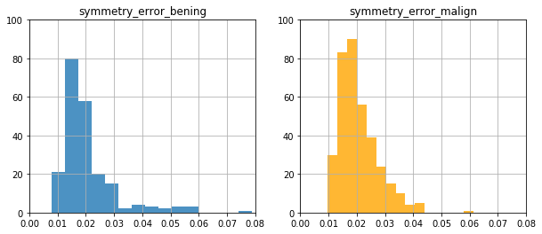

```python
#graficamos la distribución del error de la simetría (symmetry error)
fig = plt.subplots(figsize= (10,4))

plt.subplot(121)
plt.title('symmetry_error_bening')
plt.ylim(0, 100)
plt.xlim(0, 0.08)
symmetry_error_bening.hist(alpha=0.8, bins=15)

plt.subplot(122)
plt.title('symmetry_error_malign')
plt.ylim(0, 100)
plt.xlim(0, 0.08)
symmetry_error_malign.hist(alpha=0.8, bins=15, color= 'orange')

plt.show()
```

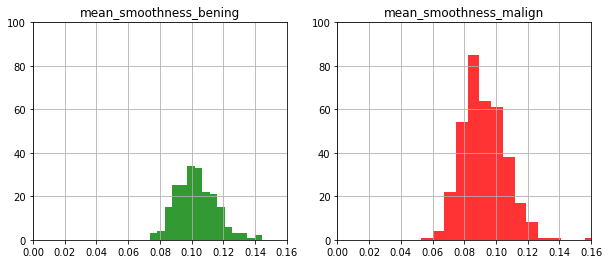

```python
#graficamos la distribución del error de tersura (mean smoothness)
fig = plt.subplots(figsize= (10,4))

plt.subplot(121)
plt.title('mean_smoothness_bening')
plt.ylim(0, 100)
plt.xlim(0, 0.16)
mean_smoothness_bening.hist(alpha=0.8, bins=15, color='g')

plt.subplot(122)
plt.title('mean_smoothness_malign')
plt.ylim(0, 100)
plt.xlim(0, 0.16)
mean_smoothness_malign.hist(alpha=0.8, bins=15, color= 'r')

plt.show()
```

```python
#realizamos el t-test estadístico sobre el error de la simetría (symmetry error)
stats.ttest_ind(symmetry_error_bening, symmetry_error_malign)
```

```
Ttest_indResult(statistic=-0.1552978000059369, pvalue=0.8766418183858812)
```

```python
#realizamos el t-test estadístico sobre el error de tersura (mean smoothness)
stats.ttest_ind(mean_smoothness_bening, mean_smoothness_malign)
```

```
Ttest_indResult(statistic=9.146098808149038, pvalue=1.0518503592032013e-18)
```

CONCLUSIÓN: El p-value pequeño obtenido en el t-test del error de tersura, nos indica que la media de los turomes malignos vs.la de los benignos es estadísticamente significativa, por lo que en principio es una caráteristica de importancia para diagnosticar los tumores.

## Ejercicio 2

Representar mediante [boxplots] (https://en.wikipedia.org/wiki/Boxplots) como varían la textura, el area, la concavidad y la simetría de los tumores según el tipo (*maligna / benigna*). Recuerda ajustar los parámetros de la visualización para facilitar la lectura e interpretación de la gráfica que generen. **(2 puntos)** NM

Nota: Crea un dataframe con los datos de `diagnostics.data` i `diagnostics.target` para dibujar los boxplots.

```python
#utilizamos el dataset creado en el ejercicio anterior
df.head()
```

|  | mean radius | mean texture | mean perimeter | mean area | mean smoothness | mean compactness | mean concavity | mean concave points | mean symmetry | mean fractal dimension | ... | worst texture | worst perimeter | worst area | worst smoothness | worst compactness | worst concavity | worst concave points | worst symmetry | worst fractal dimension | target |
| --- | --- | --- | --- | --- | --- | --- | --- | --- | --- | --- | --- | --- | --- | --- | --- | --- | --- | --- | --- | --- | --- |
| 0 | 17.99 | 10.38 | 122.80 | 1001.0 | 0.11840 | 0.27760 | 0.3001 | 0.14710 | 0.2419 | 0.07871 | ... | 17.33 | 184.60 | 2019.0 | 0.1622 | 0.6656 | 0.7119 | 0.2654 | 0.4601 | 0.11890 | 0 |
| 1 | 20.57 | 17.77 | 132.90 | 1326.0 | 0.08474 | 0.07864 | 0.0869 | 0.07017 | 0.1812 | 0.05667 | ... | 23.41 | 158.80 | 1956.0 | 0.1238 | 0.1866 | 0.2416 | 0.1860 | 0.2750 | 0.08902 | 0 |
| 2 | 19.69 | 21.25 | 130.00 | 1203.0 | 0.10960 | 0.15990 | 0.1974 | 0.12790 | 0.2069 | 0.05999 | ... | 25.53 | 152.50 | 1709.0 | 0.1444 | 0.4245 | 0.4504 | 0.2430 | 0.3613 | 0.08758 | 0 |
| 3 | 11.42 | 20.38 | 77.58 | 386.1 | 0.14250 | 0.28390 | 0.2414 | 0.10520 | 0.2597 | 0.09744 | ... | 26.50 | 98.87 | 567.7 | 0.2098 | 0.8663 | 0.6869 | 0.2575 | 0.6638 | 0.17300 | 0 |
| 4 | 20.29 | 14.34 | 135.10 | 1297.0 | 0.10030 | 0.13280 | 0.1980 | 0.10430 | 0.1809 | 0.05883 | ... | 16.67 | 152.20 | 1575.0 | 0.1374 | 0.2050 | 0.4000 | 0.1625 | 0.2364 | 0.07678 | 0 |

5 rows × 31 columns

```python
#visualizamos las columnas
df.columns
```

```
Index(['mean radius', 'mean texture', 'mean perimeter', 'mean area',
       'mean smoothness', 'mean compactness', 'mean concavity',
       'mean concave points', 'mean symmetry', 'mean fractal dimension',
       'radius error', 'texture error', 'perimeter error', 'area error',
       'smoothness error', 'compactness error', 'concavity error',
       'concave points error', 'symmetry error', 'fractal dimension error',
       'worst radius', 'worst texture', 'worst perimeter', 'worst area',
       'worst smoothness', 'worst compactness', 'worst concavity',
       'worst concave points', 'worst symmetry', 'worst fractal dimension',
       'target'],
      dtype='object')
```

```python
#seleccionamos las columnas solicitadas en el enunciado
selected_columns = ['mean texture', 'mean area', 'mean concavity']
```

```python
#filtramos el dataset con las columnas seleccionadas para el grupo de benignos
df_bening = df[df['target'] == 0][selected_columns]
df_bening.head()
```

|  | mean texture | mean area | mean concavity |
| --- | --- | --- | --- |
| 0 | 10.38 | 1001.0 | 0.3001 |
| 1 | 17.77 | 1326.0 | 0.0869 |
| 2 | 21.25 | 1203.0 | 0.1974 |
| 3 | 20.38 | 386.1 | 0.2414 |
| 4 | 14.34 | 1297.0 | 0.1980 |

```python
#filtramos el dataset con las columnas seleccionadas para el grupo de malignos
df_malign = df[df['target'] == 1][selected_columns]
df_bening.head()
```

|  | mean texture | mean area | mean concavity |
| --- | --- | --- | --- |
| 0 | 10.38 | 1001.0 | 0.3001 |
| 1 | 17.77 | 1326.0 | 0.0869 |
| 2 | 21.25 | 1203.0 | 0.1974 |
| 3 | 20.38 | 386.1 | 0.2414 |
| 4 | 14.34 | 1297.0 | 0.1980 |

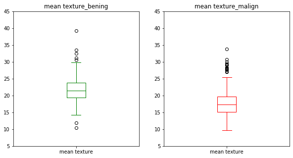

```python
#graficamos los boxplot para 'mean texture'
fig = plt.subplots(figsize= (10,5))

plt.subplot(121)
plt.title('mean texture_bening')
plt.ylim(5, 45)
plot_t_bening = df_bening['mean texture'].plot.box(vert=True, color='g')

plt.subplot(122)
plt.title('mean texture_malign')
plt.ylim(5, 45)
plot_t_malign = df_malign['mean texture'].plot.box(vert=True, color='r')
```

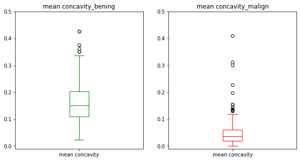

```python
#graficamos los boxplot para 'mean concavity'
fig = plt.subplots(figsize= (10,5))

plt.subplot(121)
plt.title('mean concavity_bening')
plt.ylim(-0.01, 0.5)
plot_t_bening = df_bening['mean concavity'].plot.box(vert=True, color='g')

plt.subplot(122)
plt.title('mean concavity_malign')
plt.ylim(-0.01, 0.5)
plot_t_malign = df_malign['mean concavity'].plot.box(vert=True, color = 'r')
```

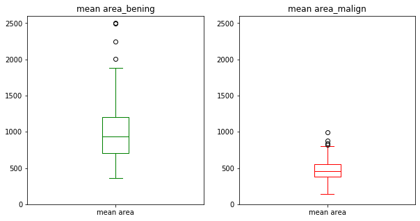

```python
#graficamos los boxplot para 'mean area'
fig, ax = plt.subplots(figsize= (10,5))

plt.subplot(121)
plt.title('mean area_bening')
plt.ylim(-0.01, 2600)
plot_t_bening = df_bening['mean area'].plot.box(vert=True, color='g')

plt.subplot(122)
plt.title('mean area_malign')
plt.ylim(-0.01, 2600)
plot_t_malign = df_malign['mean area'].plot.box(vert=True, color='r')
```

## Ejercicio 3

Ahora aplica un Principal Component Analysis para reducir el número de variables predictivas de los tipos de tumor. NM

a) ¿Qué porción de la variabilidad total la explica el primer componente? **(1.5 puntos)**

b) Representa en un diagrama de barras qué porción de la variabilidad total explica cada uno de los tres primeros componentes. **(0.5 puntos)**

```python
#importamos las librerias necesarias
from mpl_toolkits.mplot3d import Axes3D
from sklearn.decomposition import PCA
```

```python
#aplicamos PCA con los tres componentes principales
pca = PCA(n_components=3)
principalComponents = pca.fit_transform(df)
principalDf = pd.DataFrame(data = principalComponents
             , columns = ['Principal Component 1', 'Principal Component 2', 'Principal Component 3'])
```

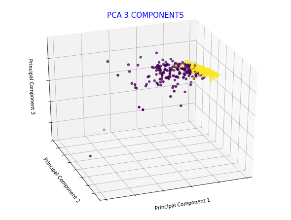

```python
#graficamos en 3 dimensiones los principal components

fig = plt.figure(1, figsize=(8, 6))
ax = Axes3D(fig, elev=-150, azim=110)
ax.scatter(principalDf.iloc[:,[0]], principalDf.iloc[:,[1]], principalDf.iloc[:,[2]], c= df['target'])

ax.set_title(u"PCA 3 COMPONENTS", fontsize=15, color='b')
ax.set_xlabel(u"Principal Component 1")
ax.w_xaxis.set_ticklabels([])
ax.set_ylabel(u"Principal Component 2")
ax.w_yaxis.set_ticklabels([])
ax.set_zlabel(u"Principal Component 3")
_ = ax.w_zaxis.set_ticklabels([])
```

```python
#Respuesta A
print('La variabilidad explicada por el "Principal Component 1" es: '
      + str(pca.explained_variance_)[1:16] + ', correspondiente al: ' +
      str(pca.explained_variance_ratio_)[1:11] + '%')
```

[output not shown]

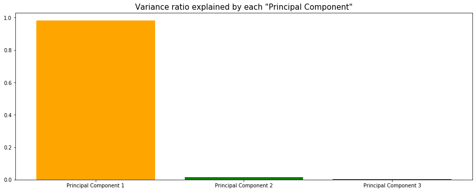

```python
#Respuesta B
columns = ['Principal Component 1', 'Principal Component 2', 'Principal Component 3']
fig = plt.figure(figsize=(16,6))
plt.title('Variance ratio explained by each "Principal Component"', fontsize=15)
plt.bar(columns, pca.explained_variance_ratio_, color= ['orange', 'g', 'b'])
plt.show()
```

## Ejercicio 4

El objetivo de un modelo de **regresión lineal** es encontrar una relación entre una o más características (variables independientes) y una variable objetivo continua (variable dependiente). Cuando sólo usamos una característica predictiva se le llama **Regresión Lineal Univariada** y si hay múltiples predictores se llama **Regresión Lineal Múltiple**.

Cuando la variable dependiente es una variable binaria que contiene datos codificados como 1 (sí, éxito, etc.) o 0 (no, fallo, etc.), como es el caso del dataset `breast_cancer`, tendremos que emplear una [regresión logística](https://ca.wikipedia.org/wiki/Regressi%C3%B3_log%C3%ADstica).

Crea un modelo de regresión logística que estime la probabilidad de que un tumor sea maligno dada su área y su textura. Muestra la [matriz de confusión](https://ca.wikipedia.org/wiki/Matriu_de_confusi%C3%B3) del modelo obtenido.

Nota: Quizás te interesa explorar la función [sklearn.metrics.confusion_matrix()](https://scikit-learn.org/stable/modules/generated/sklearn.metrics.confusion_matrix.html) **(1,5 puntos)** EI

```python
#importamos las librerias necesarias
from sklearn import linear_model
from sklearn.metrics import confusion_matrix
from sklearn.model_selection import train_test_split
```

```python
#separamos el dataset en train y test (utilizamos 0.8 para train y 0.2 para test)
X_train, X_test, y_train, y_test = train_test_split(df.loc[:,['mean area', 'mean texture', 'area error',
                                                              'texture error', 'worst area', 'worst texture']],
                                                    df['target'], test_size=.2)
```

```python
#definimos nuestro modelo de regresión logística y lo entrenamos en los dataset de Train generados anteriormente
model = linear_model.LogisticRegression(max_iter=200)
model.fit(X_train,y_train)
```

```
LogisticRegression(C=1.0, class_weight=None, dual=False, fit_intercept=True,
                   intercept_scaling=1, l1_ratio=None, max_iter=200,
                   multi_class='auto', n_jobs=None, penalty='l2',
                   random_state=None, solver='lbfgs', tol=0.0001, verbose=0,
                   warm_start=False)
```

```python
#medimos el score en nuestro dataset de entrenamiento para comprobar que no haya overfiting
model.score(X_train,y_train)
```

```
0.9472527472527472
```

```python
#medimos el score en nuevos datos (dataset Test)
model.score(X_test,y_test)
```

```
0.9473684210526315
```

```python
#realizamos las predicciones e imprimimos nuestra mattriz de confusión
predictions = model.predict(X_test)
print(confusion_matrix(y_test, predictions))
```

```
[[30  5]
 [ 1 78]]
```

[figure not shown]

## Ejercicio 5

El **Multi-layer Perceptron (MLP)** es un algoritmo de aprendizaje supervisado que aprende una función mediante el entrenamiento de un modelo que asocia n dimensiones de entrada (*predictores*) con dimensiones de salida (*targets*). Teniendo en cuenta un conjunto de funciones y un objetivo, puede aprender un aproximador de funciones no lineales por clasificación o regresión. Es diferente de la regresión logística, ya que entre la capa de entrada y la de salida, puede haber una o más capas no lineales, llamadas capas ocultas.

Aplica un clasificador basado en un MLP para predecir los tipos de tumor utilizando el área, la textura, la simetría y la concavidad, como atributos y utilizando el 70% de las muestras de entrenamiento y el 30% de test. Debéis utilizar la función [sklearn.neural_network.MLPClassifier](https://scikit-learn.org/stable/modules/neural_networks_supervised.html).

Utiliza tres niveles (*layers*) con 30 neuronas por nivel. ¿Qué valor de precisión obtenemos en un modelo basado en un MLP? **(2 puntos)** EG

```python
#importamos la librerías necesarias
from sklearn.neural_network import MLPClassifier
from sklearn.metrics import precision_score
```

```python
#visualizamos las columnas de nuestro DataFrame (df)
df.columns
```

```
Index(['mean radius', 'mean texture', 'mean perimeter', 'mean area',
       'mean smoothness', 'mean compactness', 'mean concavity',
       'mean concave points', 'mean symmetry', 'mean fractal dimension',
       'radius error', 'texture error', 'perimeter error', 'area error',
       'smoothness error', 'compactness error', 'concavity error',
       'concave points error', 'symmetry error', 'fractal dimension error',
       'worst radius', 'worst texture', 'worst perimeter', 'worst area',
       'worst smoothness', 'worst compactness', 'worst concavity',
       'worst concave points', 'worst symmetry', 'worst fractal dimension',
       'target'],
      dtype='object')
```

```python
#seleccionamos las columnas según el enunciado
selected_columns = ['mean area', 'mean texture', 'mean concavity', 'mean symmetry', 'texture error', 'area error',
 'concavity error', 'symmetry error', 'worst texture', 'worst area', 'worst concavity',
 'worst symmetry']
```

```python
#separamos el dataset en train y test (utilizamos 70% para train y 30% para test según enunciado)
X_train, X_test, y_train, y_test = train_test_split(df.loc[:,selected_columns],
                                                    df['target'], test_size=.3, random_state=100)
```

```python
#definimos nuestro modelo de 3 niveles y 30 hidden layers
# *utilizamos verbose para ver la evolución de las iteraciones
clf = MLPClassifier(hidden_layer_sizes=(3,30), max_iter=700, verbose=True,
                    activation= 'relu', random_state=100)
```

```python
#entrenamos nuestro modelo en los datasets generados para ello
clf.fit(X_train, y_train)
```

[output not shown]

[output cut: 199 more lines]

[output not shown]

```
MLPClassifier(activation='relu', alpha=0.0001, batch_size='auto', beta_1=0.9,
              beta_2=0.999, early_stopping=False, epsilon=1e-08,
              hidden_layer_sizes=(3, 30), learning_rate='constant',
              learning_rate_init=0.001, max_fun=15000, max_iter=700,
              momentum=0.9, n_iter_no_change=10, nesterovs_momentum=True,
              power_t=0.5, random_state=100, shuffle=True, solver='adam',
              tol=0.0001, validation_fraction=0.1, verbose=True,
              warm_start=False)
```

```python
#realizamos las predicciones e imprimimos nuestra mattriz de confusión
predictions = clf.predict(X_test)
print(confusion_matrix(y_test, predictions))
```

```
[[ 61   8]
 [  2 100]]
```

[figure not shown]

### PRECISION:

Definimos **precisión** como el raito de TP / (TP + FP). Para calcularla planteamos dos opciones:

```python
#OPCIÓN 1: Podemos calcularlo a mano con los valores obtenidos en nuestra matriz
precision = 100/(100+8)
precision
```

```
0.9259259259259259
```

```python
#OPCIÓN 2: Utilizamos sklearn "precision_score"    *podemos observar que ambos nos devuelven el mismo valor
precision_score(y_test, predictions)
```

```
0.9259259259259259
```

## Ejercicio Opcional

Aplicad un clasificador basado en un [árbol de decicisión](https://es.wikipedia.org/wiki/Árbol_de_decisión) de un máximo de 3 niveles de profundidad para predecir los tipos de tumor utilizando el area, la tersura y la simetría como atributos y utilizando 60% de las muestras de entrenamiento y el 40% de test. Debéis utilizar la función [sklearn.tree.DecisionTreeClassifier](https://scikit-learn.org/stable/modules/generated/sklearn.tree.DecisionTreeClassifier.html).

¿Qué valor de precisión obtenemos en un modelo basado en un árbol de decisión? Representa el árbol de decisión y expórtalo a un archivo PDF. Explora el árbol resultante al PDF y responde a la siguiente pregunta: Dados estos datos, cómo diagnosticarías a un paciente que presenta un tumor de area 400, textura 12.18, y un valor de lisura de 19 puntos?

Nota: Tal vez la función [tree](https://scikit-learn.org/stable/modules/tree.html) de *sklearn* sea de utilidad. EG

```python
#importamos las librerias necesarias
from sklearn.tree import DecisionTreeClassifier
from sklearn import tree
import graphviz
```

```python
#separamos el dataset en train y test (utilizamos 60% para train y 40% para test según enunciado)
X_train, X_test, y_train, y_test = train_test_split(df.loc[:,['mean area', 'mean texture', 'mean symmetry']],
                                                    df['target'], test_size=.4)
```

```python
#definimos nuestro modelo y lo entrenamos en los dataset de Train generados anteriormente
clf2 = tree.DecisionTreeClassifier(max_depth=3)
clf2 = clf2.fit(X_train, y_train)
```

```python
#medimos el score en nuestro dataset de test
clf2.score(X_test, y_test)
```

```
0.8991228070175439
```

```python
#visualizamos nuestro árbol de decision
dot_data = tree.export_graphviz(clf2, out_file=None, feature_names=X_train.columns,
                                filled=True, rounded=True,
                                special_characters=True)

graph = graphviz.Source(dot_data)
graph
```

[figure not shown]

```python
#exportamos nuestro dataset a pdf utilizando la librería graphviz
graph.render("clf2")
```

```
'clf2.pdf'
```

Con estos datos ¿cómo diagnosticarías a un paciente que presenta un tumor de area 400, simetría 0.18 y un valor de textura de 19 puntos?

```python
#creamos un dataset con nuestros datos a predecir
test = pd.DataFrame(data=[[400, 19, 0.18]], columns= ['area', 'texture', 'simetry'])
test
```

|  | area | texture | simetry |
| --- | --- | --- | --- |
| 0 | 400 | 19 | 0.18 |

```python
#hacemos la predicción y obtenemos el resultado
print(clf2.predict(test))
```

```
[1]
```